# Entregable - Names - Natalia

Natalia Gavaldá

2024-11-03

## Gráficos de líneas

El conjunto de datos babynames contiene información sobre nombres de niños y niñas y sus frecuencias de uso. Se eligen los nombre Mary y James para la elaboración del ejercicio.

Además, en el dataset escogido ambos nombres pueden ser escogidos para el sexo femenino y masculino. Para la elaboración del gráfico se escogeran los registros del sexo femenino para Mary y aquellos del sexo masculino para James.

```r
# Librerías
library(babynames)
library(ggplot2)

# Nombres elegidos: "Mary" y "James"
selected_names <- c("Mary", "James")
data_filtered <- babynames[(babynames$name == "Mary" & babynames$sex == "F") |
                             (babynames$name == "James" & babynames$sex == "M"), ]

head(data_filtered)
```

```
## # A tibble: 6 × 5
##    year sex   name      n   prop
##   <dbl> <chr> <chr> <int>  <dbl>
## 1  1880 F     Mary   7065 0.0724
## 2  1880 M     James  5927 0.0501
## 3  1881 F     Mary   6919 0.0700
## 4  1881 M     James  5441 0.0502
## 5  1882 F     Mary   8148 0.0704
## 6  1882 M     James  5892 0.0483
```

## Gráfico

Creación del gráfico de líneas para la evolución en el tiempo de ambos nombres.

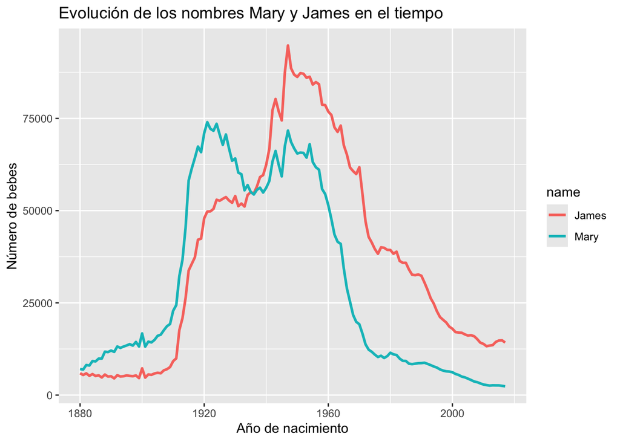

```r
ggplot(data_filtered, aes(x = year, y = n, color=name)) +
  labs(title = "Evolución de los nombres Mary y James en el tiempo",
       x = "Año de nacimiento",
       y = "Número de bebes") + geom_line(size=1)
```

## Conclusiones

El gráfico nos muestra la evolución del número de bebes llamados Mary y James. Al superponer ambas series de datos podemos comparar ambas series.

Se observa que el nombre “Mary” fue muy popular entre 1900 y 1950, alcanzando su pico máximo a mediados de ese periodo.A partir de ahí, su uso comenzó a disminuir de forma gradual hasta llegar a niveles muy bajos a partir del año 2000.